# Project 2: Creating a Synthetic Population of Eswatini

Emilio Luz-Ricca

# 1 Brief Outline

In this project, I focused on putting together a synthetic population of Eswatini. I used DHS household survey data from 2006 to accomplish this goal. Using the results of this project and Project 1, I will begin to predict movement decisions in Project 3 using the gravity model.

# 2 Acquiring, Reading, and Wrangling the Data

Acquiring the data from DHS was actually relatively easy, only requiring a few pieces of writing to justify the use of the household survey data and the GPS data. I covered this step in more detail in my [Project 2 outline](https://emiliolr.github.io/abm/project_2_outline.html).

After getting the data, I read it in with `haven` and began to explore the data. The data set includes a total of 4843 households. Pulling out the desired variables was pretty easy, although some work was required to find the right variables from the more than 4000 variables in the data set (it didn’t help that there was no accompanying .do file to work with). In the end, I pulled out the variables for number of household members, the sex of members, the age of members, the region identifier (first level administrative subdivisions), and the sample weights (the data is not self-weighting at the national level).

# 3 Assigning Locations to the Households

Assigning feasible locations to each household would have been more important in a more detailed analysis, but, since I had time, I completed this step anyway. In the end, I used two methods here, one less precise and one much more precise. The less precise method used the underlying population density (extracted from a 2006 population raster) as the basis for several `spatstat::rpoint()` commands (one for each region in Eswatini). Then, I joined these feasible locations (accurate to the region-level) back to the original data. The following plot shows the result, with points colored by the region that they should have ended up in to ensure that each point found it’s way to a house in the correct region.

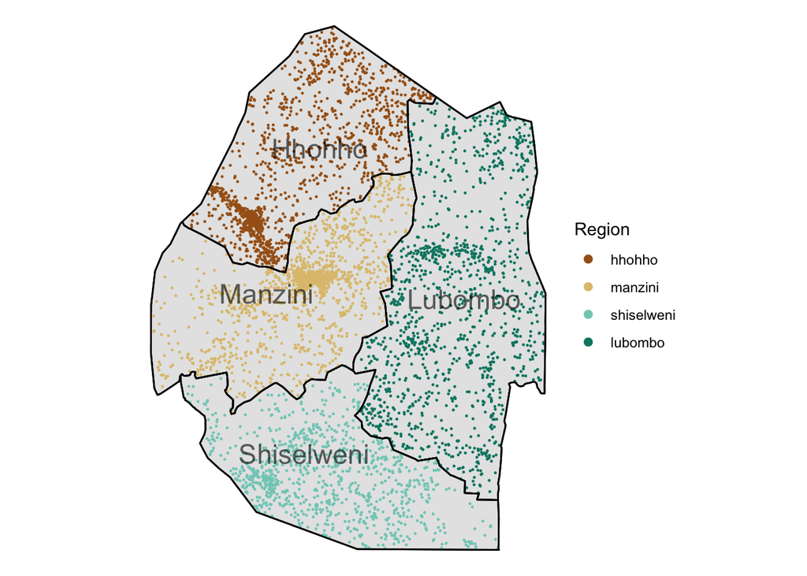

Since I had received the GPS data from DHS as well, I also worked on the stretch goal of placing each household in its correct cluster. This required considerably more work than the previous method, leveraging a number of different spatial operations from the `sf` library. Clusters were identified by their center point in the data set and points needed to be distributed in either a 2, 5, or 10 kilometer radius depending on if the cluster was urban or rural (a 1% random sample of the rural clusters were distributed in a 10 kilometer radius, as specified in the [DHS methods documentation](https://dhsprogram.com/pubs/pdf/SAR11/SAR11.pdf)). Also, all houses in a given cluster had to be distributed in the same region as their cluster center point, so expanded cluster areas could not cross first level administrative subdivisions (or Eswatini’s international border). The following plot shows the result of this process.

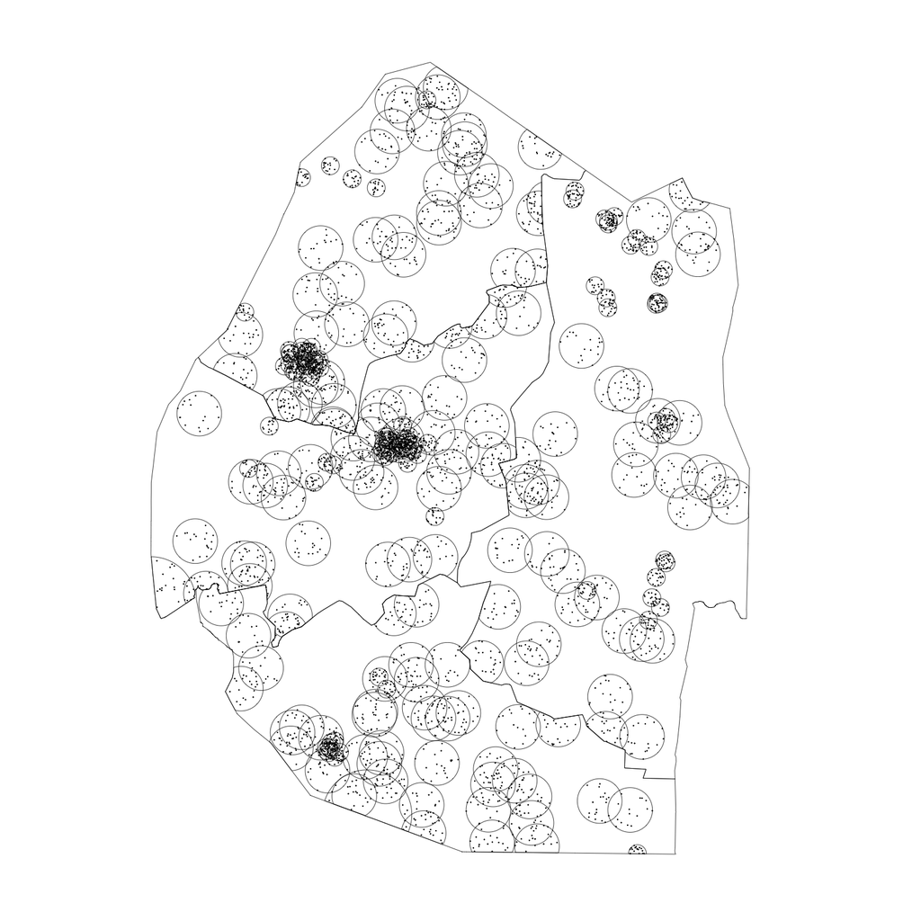

Some clusters didn’t have an assigned center point in the GPS data. For the households in these clusters, I simply distributed them across their correct regions with `spatstat::rpoint()`. The following plot includes all located households, with households in clusters that are missing GPS data in red.

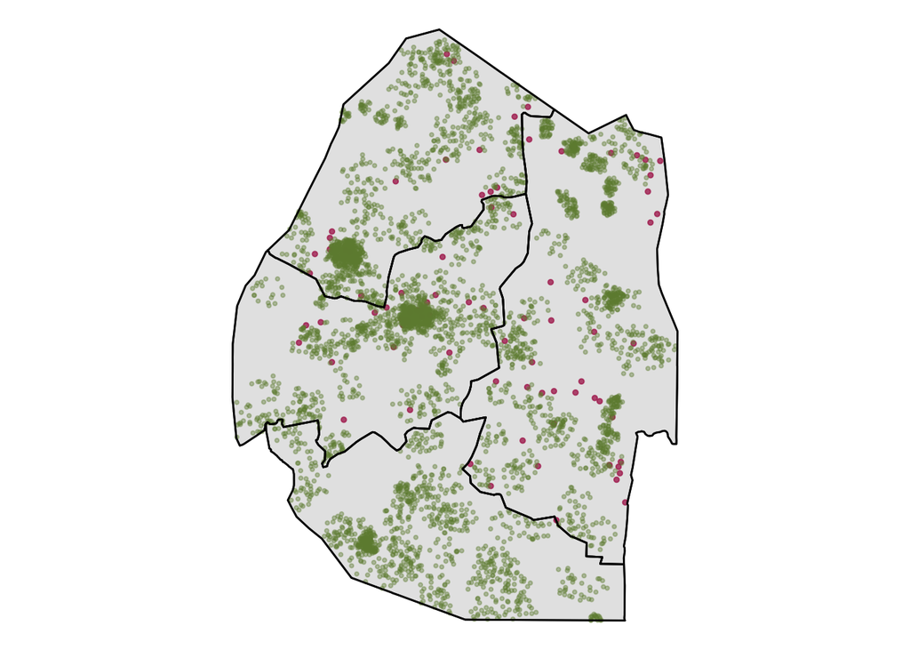

# 4 Producing the Synthetic Population

Unfortunately, I didn’t have time to meaningfully use the elements from the previous steps. Instead, we made some simplifying assumptions as a class and forged ahead with synthetic population creation. Any spatial allocation used in the subsequent steps simply leveraged a nation-level `spatstat::rpoint()` function, which didn’t respect the region-level location ID included in the DHS household survey or the GPS data for cluster centers.

I was able to check basic error in the procedure along two axes: deviation from true population total and error caused by ignoring the weights. In both cases, error was quite small: $\approx$ 0.65% deviation from the population total and $\approx$ 3.42% error from ignoring the weights. This is pretty good, but certainly an area for improvement in a more refined analysis; integrating the sample weights into the analysis certainly would help a lot. I talk more about further areas for improvement in the next section.

# 5 Results

As discussed in class, spatial and demographic accuracy for this synthetic population is on a spectrum. On one end, household locations are distributed randomly and demographic features are generated at random (or perhaps drawn off of a normal distribution); on the other end, a population-wide census ensures data that is spatially and demographically as accurate as possible (allowing for nominal error due to inaccurate reporting or other factors). While the method used here certainly doesn’t approach the accuracy of a census, I argue in this section that our final synthetic population and accompanying random forest model, which could be extended to fold in more variables, does a “pretty good” job of approximating spatial and demographic features in the *aggregate*.

The basis for this argument is mostly qualitative. First, I’ve plotted the empirical distributions for our three “shell” variables (sex, age, and household size) for both the survey data (the true “distribution,” as far as we know) and the shell data.

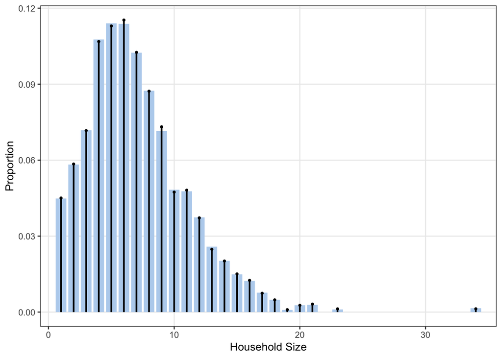

In this first plot, I have the distribution for the DHS data in greyish-blue and the shell data in black. We can pretty clearly see that the empirical distribution from the DHS survey data is well respected, with the two distributions aligning almost perfectly in most cases.

Next, we have distribution of sex

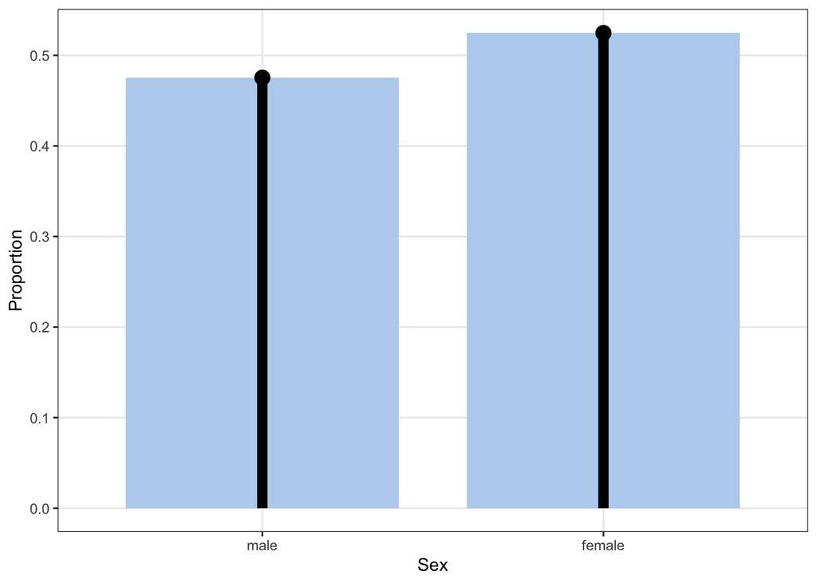

The plot is probably unnecessary here, but once again we can see that the distribution differs very little between the survey and shell data.

And finally, we can look at the distribution of ages.

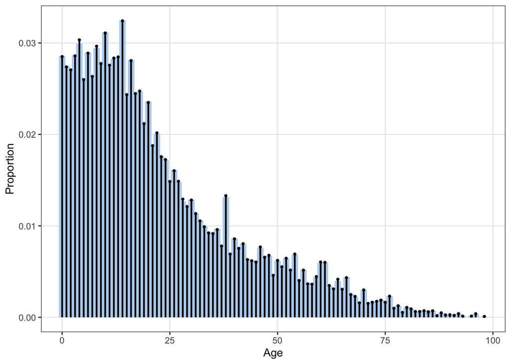

Age distribution from the survey data is also well respected in the shell data. The point here is that, across our shell variables, I have made sure to respect the aggregate patterns seen in the survey data. This preserves at least a basic level of empirical accuracy that would be lost if we were to generate these variables randomly or even if we were to model these variables using standard distributions (which would require additional work to choose suitable parameters). None of this is too surprising: given that I’ve only resampled with replacement up to this point, this is what we should expect.

If I’ve done a good job capturing these underlying distributions, as I begin to model and fold in predictor variables, we should continue to see that the underlying distributions are preserved. The next plot shows the distributions for education level from the survey and from the *synthetic population*, although the education level variable in the synthetic population was predicted using a random forest model (not just resampled with replacement).

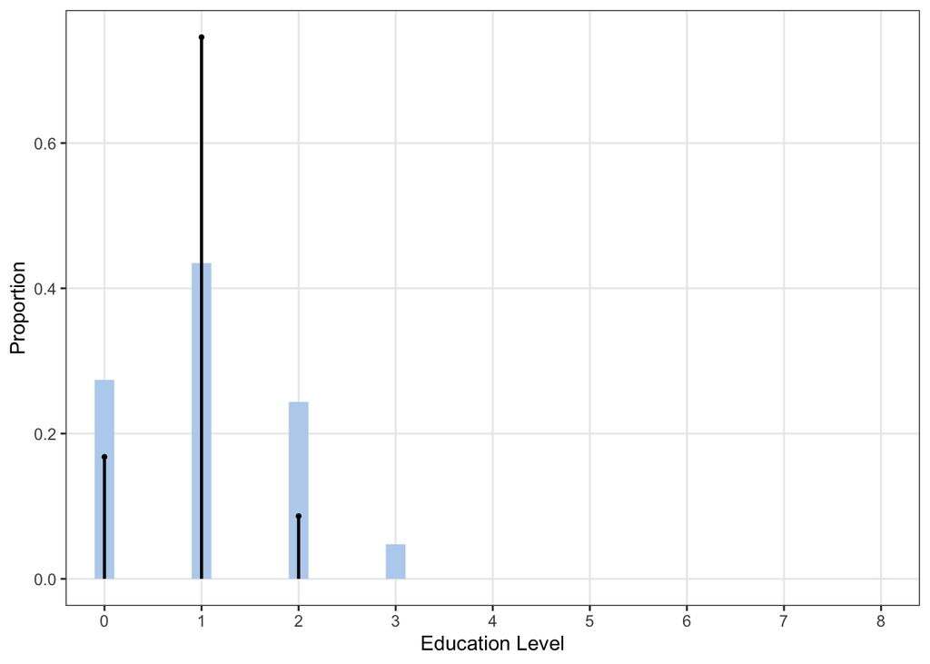

Turning to spatial accuracy, the next few plots shows the result of a uniform allocation of households across Eswatini versus an allocation that respects the underlying population density (as extracted from a raster).

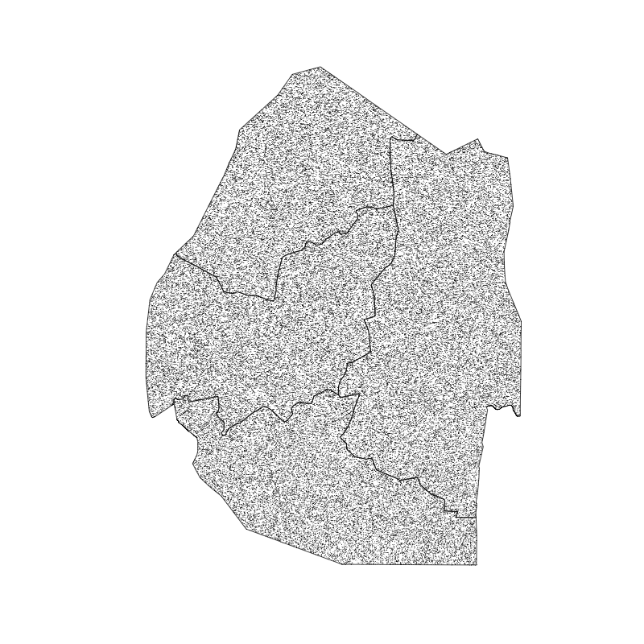

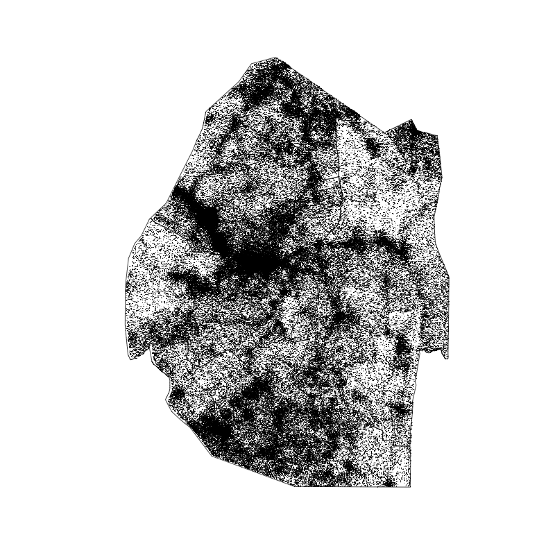

While neither of these does nearly as well as the allocation of points within their actual DHS cluster (see a few sections above), the second certainly does a much better job of respecting spatial distributions. The first basically amounts to spatial noise, while the second is much more true to life.

# 6 Sharing the Scripts

Since there weren’t a huge amount of resources out there for assigning the households locations based on the GPS data, I’m including a link to [my solution](https://github.com/emiliolr/abm/blob/master/backup/modeling_households_gps.R).